# USL - In-Class Lab Exercise (Week-2-Part-1) - Questions

|  | Inclass-Lab (Day 2) |
| --- | --- |

## 9 participants so far. Welcome to week 2 session for USL.

## We'll wait few minutes for everyone to join comfortably.

## I'll be audible from 09:40 AM sharp.

### About the dataset (CO<sub>2</sub> emission data)

In the dataset, the CO<sub>2</sub> emission for various regions in the world is given. Our objective is to group the regions based on the factors affecting the environment in terms of the greenhouse gases, where CO<sub>2</sub> is a primary greenhouse gas.

Many developing and developed countries in the world are contributing to the CO<sub>2</sub> emission in the environment. It is interesting to know that the increase in atmospheric carbon dioxide is responsible for about two-thirds of the total energy imbalance that is causing Earth's temperature to rise and leads to global warming.

**Region**: Region of the country

**CO2 Emission**: Annual CO<sub>2</sub> emission (in tonnes)

**Ease of Business**: The ease of business in the country

**Energy Usage**: Energy used by the country in various forms

**GDP**: GDP of a country

**Internet Usage**: Usage of the internet

**Population total**: Total population of a country

## Table of Content

1. **Exploratory Data Analysis**
2. **Hierarchical Clustering**
3. **DBSCAN**

#### Import the required libraries

```python
import numpy as np
import matplotlib.pyplot as plt
import pandas as pd
import seaborn as sns
```

#### Read the data

Load the csv file and print the first five observations.

```python
df_CO2 = pd.read_csv('F:/Games & Jars/NewErp/Inclass/CO2_emission_data.csv')
df_CO2
```

|  | Region | CO2 Emissions | Ease of Business | Energy Usage | GDP | Internet Usage | Population Total |
| --- | --- | --- | --- | --- | --- | --- | --- |
| 0 | Europe | 4294 | 151 | 1976 | 5.652325e+09 | 0.010 | 3033659 |
| 1 | Europe | 4166 | 151 | 2172 | 7.464447e+09 | 0.024 | 3014579 |
| 2 | Europe | 4254 | 151 | 2172 | 8.376484e+09 | 0.060 | 2992724 |
| 3 | Europe | 3865 | 151 | 2068 | 9.132562e+09 | 0.096 | 2968028 |
| 4 | Europe | 4056 | 151 | 2025 | 1.070101e+10 | 0.150 | 2940880 |
| ... | ... | ... | ... | ... | ... | ... | ... |
| 1238 | Africa | 2274 | 90 | 7213 | 7.178556e+09 | 0.029 | 11470022 |
| 1239 | Africa | 2226 | 90 | 7396 | 1.070220e+10 | 0.042 | 11781612 |
| 1240 | Africa | 1654 | 90 | 7399 | 1.154142e+10 | 0.049 | 12109620 |
| 1241 | Africa | 1845 | 90 | 7641 | 1.464079e+10 | 0.056 | 12456527 |
| 1242 | Africa | 2156 | 90 | 7842 | 1.280503e+10 | 0.063 | 12825031 |

1243 rows × 7 columns

### Let's begin with some hands-on practice exercises

## 1. Exploratory Data Analysis

|  | **1. Identify the different regions to which the countries belong and visualize the count of countries.** |
| --- | --- |

```python
df_CO2.columns
```

```
Index(['Region', 'CO2 Emissions', 'Ease of Business', 'Energy Usage', 'GDP',
       'Internet Usage', 'Population Total'],
      dtype='object')
```

```python
df_CO2['Region'].value_counts()
```

```
Europe          302
The Americas    289
Africa          254
Asia            244
Middle East      92
Oceania          62
Name: Region, dtype: int64
```

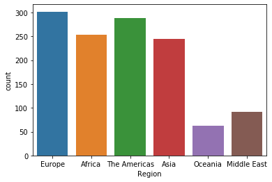

```python
sns.countplot(df_CO2['Region'])
plt.show()
```

|  | **2. Check the datatype, dimension and summary statistics of the data.** |
| --- | --- |

```python
print(df_CO2.dtypes)
print(df_CO2.shape)
df_CO2.describe()
```

```
Region               object
CO2 Emissions         int64
Ease of Business      int64
Energy Usage          int64
GDP                 float64
Internet Usage      float64
Population Total      int64
dtype: object
(1243, 7)
```

|  | CO2 Emissions | Ease of Business | Energy Usage | GDP | Internet Usage | Population Total |
| --- | --- | --- | --- | --- | --- | --- |
| count | 1.243000e+03 | 1243.000000 | 1.243000e+03 | 1.243000e+03 | 1236.000000 | 1.243000e+03 |
| mean | 1.897666e+05 | 88.279968 | 7.541842e+04 | 3.535548e+11 | 0.329983 | 4.513494e+07 |
| std | 7.697027e+05 | 52.770388 | 2.707586e+05 | 1.358970e+12 | 1.634042 | 1.600483e+08 |
| min | 4.800000e+01 | 1.000000 | 3.000000e+01 | 1.232585e+08 | 0.000000 | 6.966000e+04 |
| 25% | 3.111500e+03 | 45.000000 | 2.721000e+03 | 7.746581e+09 | 0.062000 | 2.097088e+06 |
| 50% | 1.620800e+04 | 85.000000 | 9.318000e+03 | 2.468037e+10 | 0.200500 | 7.739900e+06 |
| 75% | 7.581200e+04 | 131.000000 | 3.495650e+04 | 1.770000e+11 | 0.460000 | 2.884664e+07 |
| max | 8.286892e+06 | 186.000000 | 2.727728e+06 | 1.620000e+13 | 57.000000 | 1.350695e+09 |

|  | **3. Drop the variables 'Region', 'Ease of Business', 'Internet Usage'.** |
| --- | --- |

```python
df_CO2 = df_CO2.drop(['Region', 'Ease of Business', 'Internet Usage'], axis = 1)
df_CO2
```

|  | CO2 Emissions | Energy Usage | GDP | Population Total |
| --- | --- | --- | --- | --- |
| 0 | 4294 | 1976 | 5.652325e+09 | 3033659 |
| 1 | 4166 | 2172 | 7.464447e+09 | 3014579 |
| 2 | 4254 | 2172 | 8.376484e+09 | 2992724 |
| 3 | 3865 | 2068 | 9.132562e+09 | 2968028 |
| 4 | 4056 | 2025 | 1.070101e+10 | 2940880 |
| ... | ... | ... | ... | ... |
| 1238 | 2274 | 7213 | 7.178556e+09 | 11470022 |
| 1239 | 2226 | 7396 | 1.070220e+10 | 11781612 |
| 1240 | 1654 | 7399 | 1.154142e+10 | 12109620 |
| 1241 | 1845 | 7641 | 1.464079e+10 | 12456527 |
| 1242 | 2156 | 7842 | 1.280503e+10 | 12825031 |

1243 rows × 4 columns

|  | **4. Check if there are missing values, if yes then remove the observations with missing values.** |
| --- | --- |

```python
df_CO2.isnull().sum()
```

```
CO2 Emissions       0
Energy Usage        0
GDP                 0
Population Total    0
dtype: int64
```

|  | **5. Check if there are outliers in the data and visualize the outliers using a boxplot.** |
| --- | --- |

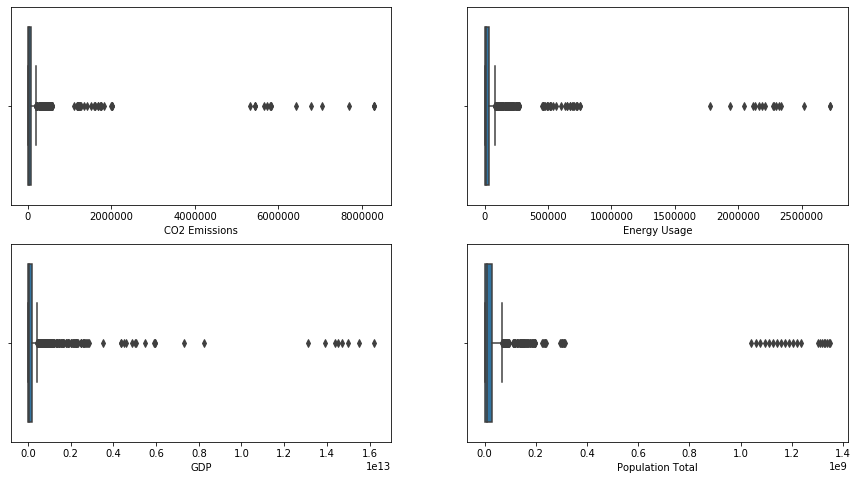

```python
fig, ax = plt.subplots(nrows = 2, ncols = 2, figsize=(15, 8))

for variable, subplot in zip(df_CO2.columns, ax.flatten()):
    sns.boxplot(df_CO2[variable], ax = subplot)
plt.show()
```

|  | **6. Remove the outliers using 3.5IQR and check the shape of the data.** |
| --- | --- |

```python
q1 = df_CO2.quantile(0.25)
q3 = df_CO2.quantile(0.75)
iqr = q3 - q1

df_CO2 = df_CO2[~((df_CO2 < (q1 - 3.5 * iqr)) | (df_CO2 > (q3 + 3.5 * iqr))).any(axis = 1)]
df_CO2
```

|  | CO2 Emissions | Energy Usage | GDP | Population Total |
| --- | --- | --- | --- | --- |
| 0 | 4294 | 1976 | 5.652325e+09 | 3033659 |
| 1 | 4166 | 2172 | 7.464447e+09 | 3014579 |
| 2 | 4254 | 2172 | 8.376484e+09 | 2992724 |
| 3 | 3865 | 2068 | 9.132562e+09 | 2968028 |
| 4 | 4056 | 2025 | 1.070101e+10 | 2940880 |
| ... | ... | ... | ... | ... |
| 1238 | 2274 | 7213 | 7.178556e+09 | 11470022 |
| 1239 | 2226 | 7396 | 1.070220e+10 | 11781612 |
| 1240 | 1654 | 7399 | 1.154142e+10 | 12109620 |
| 1241 | 1845 | 7641 | 1.464079e+10 | 12456527 |
| 1242 | 2156 | 7842 | 1.280503e+10 | 12825031 |

1054 rows × 4 columns

|  | **7. Visualize the data obtained after removing the outliers with the help of a boxplot.** |
| --- | --- |

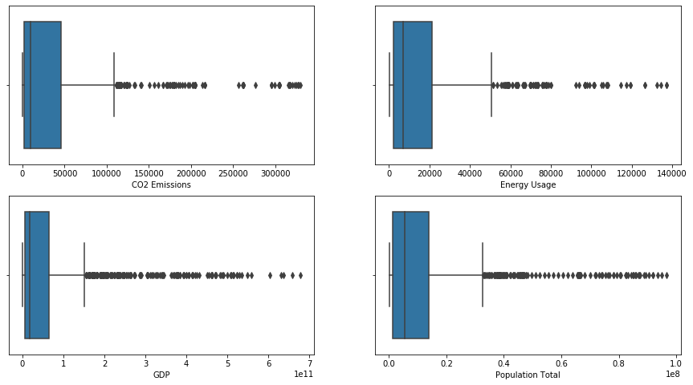

```python
fig, ax = plt.subplots(nrows = 2, ncols = 2, figsize=(15, 8))

for variable, subplot in zip(df_CO2.columns, ax.flatten()):
    sns.boxplot(df_CO2[variable], ax = subplot)
plt.show()
```

|  | **8. Transform the variables in the standard form such that they will have mean 0 and standard deviation 1 and get the summary.** |
| --- | --- |

```python
from sklearn.preprocessing import StandardScaler
sc = StandardScaler()
df_CO2 = pd.DataFrame(sc.fit_transform(df_CO2), columns = df_CO2.columns)
df_CO2.describe()
```

|  | CO2 Emissions | Energy Usage | GDP | Population Total |
| --- | --- | --- | --- | --- |
| count | 1.054000e+03 | 1.054000e+03 | 1.054000e+03 | 1.054000e+03 |
| mean | 1.170264e-16 | 1.017529e-16 | 4.650507e-17 | -1.628221e-16 |
| std | 1.000475e+00 | 1.000475e+00 | 1.000475e+00 | 1.000475e+00 |
| min | -5.951436e-01 | -7.003763e-01 | -5.936172e-01 | -6.843682e-01 |
| 25% | -5.556345e-01 | -6.130414e-01 | -5.458443e-01 | -6.156072e-01 |
| 50% | -4.348687e-01 | -3.975408e-01 | -4.468020e-01 | -3.957295e-01 |
| 75% | 1.737150e-01 | 2.374497e-01 | -4.569213e-02 | 7.324626e-02 |
| max | 4.951400e+00 | 5.315282e+00 | 5.152770e+00 | 4.580071e+00 |

## 2. Hierarchical Clustering

|  | **9. Use the 'ward' linkage method and print the first 10 observations of the linkage matrix.** |
| --- | --- |

```python
from scipy.cluster.hierarchy import linkage
link_mat = linkage(df_CO2, method = 'ward')
print(link_mat[0:10])
```

```
[[3.80000000e+02 3.82000000e+02 2.25694801e-05 2.00000000e+00]
 [3.91000000e+02 3.92000000e+02 3.78208913e-05 2.00000000e+00]
 [3.81000000e+02 3.83000000e+02 8.63012142e-05 2.00000000e+00]
 [3.60000000e+01 3.70000000e+01 8.78688205e-05 2.00000000e+00]
 [2.60000000e+01 2.70000000e+01 1.07365323e-04 2.00000000e+00]
 [4.95000000e+02 4.96000000e+02 1.19667619e-04 2.00000000e+00]
 [3.84000000e+02 3.85000000e+02 1.20059668e-04 2.00000000e+00]
 [8.16000000e+02 8.18000000e+02 1.41060028e-04 2.00000000e+00]
 [9.60000000e+02 9.61000000e+02 1.45534666e-04 2.00000000e+00]
 [3.89000000e+02 3.90000000e+02 1.48856642e-04 2.00000000e+00]]
```

```python
link_mat = pd.DataFrame(link_mat, columns = ['1st Obs', '2nd Obs', 'Euclidean Distance', 'No of obs in the cluster'])
link_mat
```

|  | 1st Obs | 2nd Obs | Euclidean Distance | No of obs in the cluster |
| --- | --- | --- | --- | --- |
| 0 | 380.0 | 382.0 | 0.000023 | 2.0 |
| 1 | 391.0 | 392.0 | 0.000038 | 2.0 |
| 2 | 381.0 | 383.0 | 0.000086 | 2.0 |
| 3 | 36.0 | 37.0 | 0.000088 | 2.0 |
| 4 | 26.0 | 27.0 | 0.000107 | 2.0 |
| ... | ... | ... | ... | ... |
| 1048 | 2091.0 | 2097.0 | 17.748770 | 135.0 |
| 1049 | 2093.0 | 2099.0 | 19.181210 | 820.0 |
| 1050 | 2100.0 | 2102.0 | 29.903428 | 178.0 |
| 1051 | 2101.0 | 2104.0 | 32.905933 | 234.0 |
| 1052 | 2103.0 | 2105.0 | 65.583639 | 1054.0 |

1053 rows × 4 columns

|  | **10. Visualize the clusters obtained using dendrogram and find the optimal number of clusters.** |
| --- | --- |

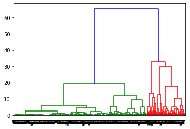

```python
from scipy.cluster.hierarchy import dendrogram
dendro = dendrogram(link_mat.values)

# Optimal number of cluster = 2
```

|  | **11. Find the cophenetic correlation coefficient and interpret it.** |
| --- | --- |

```python
from scipy.cluster.hierarchy import cophenet
from sklearn.metrics.pairwise import euclidean_distances

ec = euclidean_distances(df_CO2)
dist_array = ec[np.triu_indices(1054, k = 1)]
coeff, cophenet_dist = cophenet(link_mat.values, dist_array)
print(coeff)

# The clustering algo is working properly
# If the value of cophenet < 0.5, we would have written that the clustering algorithm is not able to separate the data
# properly.
```

```
0.7973822617121825
```

|  | **12. Instantiate clustering method with an optimal number of clusters and 'ward' linkage method.** |
| --- | --- |

```python
# optimal clusters = 2
# linkage = 'ward'

from sklearn.cluster import AgglomerativeClustering
hca = AgglomerativeClustering(n_clusters = 2, linkage = 'ward')
hca.fit(df_CO2)
```

```
AgglomerativeClustering()
```

|  | **13. Obtain the cluster labels and add a column containing the cluster number to the original data.** |
| --- | --- |

```python
# hca.fit_predict(df_CO2)
df_CO2['Cluster'] = hca.labels_
df_CO2
```

|  | CO2 Emissions | Energy Usage | GDP | Population Total | Cluster |
| --- | --- | --- | --- | --- | --- |
| 0 | -0.523682 | -0.615122 | -0.546747 | -0.522900 | 1 |
| 1 | -0.525836 | -0.606536 | -0.531386 | -0.523940 | 1 |
| 2 | -0.524355 | -0.606536 | -0.523654 | -0.525130 | 1 |
| 3 | -0.530902 | -0.611092 | -0.517245 | -0.526476 | 1 |
| 4 | -0.527688 | -0.612976 | -0.503949 | -0.527955 | 1 |
| ... | ... | ... | ... | ... | ... |
| 1049 | -0.557679 | -0.385690 | -0.533809 | -0.063318 | 1 |
| 1050 | -0.558487 | -0.377673 | -0.503939 | -0.046343 | 1 |
| 1051 | -0.568114 | -0.377542 | -0.496825 | -0.028475 | 1 |
| 1052 | -0.564900 | -0.366940 | -0.470552 | -0.009577 | 1 |
| 1053 | -0.559665 | -0.358134 | -0.486113 | 0.010498 | 1 |

1054 rows × 5 columns

|  | **14. Find the size of each cluster and plot the count plot for the cluster size.** |
| --- | --- |

```python
df_CO2['Cluster'].value_counts()
```

```
1    820
0    234
Name: Cluster, dtype: int64
```

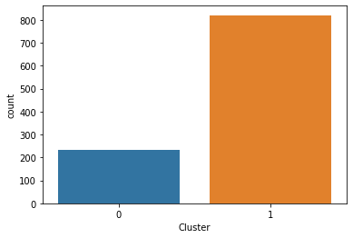

```python
sns.countplot(df_CO2['Cluster'])
plt.show()
```

|  | **15. Plot the scatterplot to visualize the clusters using 'CO2 Emissions' and 'Energy Usage'.** |
| --- | --- |

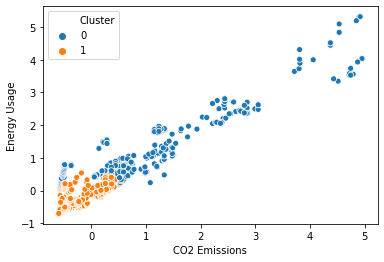

```python
sns.scatterplot(x = 'CO2 Emissions', y = 'Energy Usage', data = df_CO2, hue = 'Cluster')
plt.show()

# Insight: There is a linear relationship between Energy usage and CO2 emission.
# The regions that use more energy are more likely to contribute to global warming.

# Regions that fall in cluster 1 don't contribute a lot to global warming as they don't use a lot of energy.
# Take real world decisions for the regions in cluster 0.
```

[output not shown]

```python
# Non-CO2 contributing regions
# Cluster no 1

df_CO2[df_CO2['Cluster'] == 1].describe()
```

|  | CO2 Emissions | Energy Usage | GDP | Population Total | Cluster |
| --- | --- | --- | --- | --- | --- |
| count | 820.000000 | 820.000000 | 820.000000 | 820.000000 | 820.0 |
| mean | -0.382092 | -0.423239 | -0.402942 | -0.307862 | 1.0 |
| std | 0.267401 | 0.300781 | 0.275042 | 0.504407 | 0.0 |
| min | -0.595144 | -0.700376 | -0.593617 | -0.684368 | 1.0 |
| 25% | -0.570656 | -0.668461 | -0.565776 | -0.646452 | 1.0 |
| 50% | -0.497233 | -0.530087 | -0.497357 | -0.487466 | 1.0 |
| 75% | -0.279441 | -0.300557 | -0.373034 | -0.175678 | 1.0 |
| max | 0.535752 | 0.590743 | 1.126177 | 2.171155 | 1.0 |

[output not shown]

```python
# CO2 contributing regions
# Cluster no 0

df_CO2[df_CO2['Cluster'] == 0].describe()
```

|  | CO2 Emissions | Energy Usage | GDP | Population Total | Cluster |
| --- | --- | --- | --- | --- | --- |
| count | 234.000000 | 234.000000 | 234.000000 | 234.000000 | 234.0 |
| mean | 1.338954 | 1.483147 | 1.412020 | 1.078833 | 0.0 |
| std | 1.399278 | 1.168768 | 1.297666 | 1.458375 | 0.0 |
| min | -0.558487 | 0.173235 | -0.529329 | -0.614123 | 0.0 |
| 25% | 0.477275 | 0.638813 | 0.507353 | -0.192570 | 0.0 |
| 50% | 1.005628 | 1.049498 | 1.143131 | 0.810836 | 0.0 |
| 75% | 2.092798 | 2.053323 | 2.300247 | 1.809779 | 0.0 |
| max | 4.951400 | 5.315282 | 5.152770 | 4.580071 | 0.0 |